# OSEM Illustration Germany

Jonas Kurle

2024-12-10

```r
#devtools::install_github("moritzpschwarz/osem", ref = "main")
library(osem)
library(tidyverse)
```

# Model Overview

We model the demand and the supply side separately.

$$\begin{align}
\text{Supply} & = \text{GDPOutput} + \text{Imports} \\
\text{Demand} & = \text{GDPExpenditure} + \text{Imports} \\
\end{align}$$
To model the supply side, $\text{GDPOutput}$ is first decomposed into its components.

$$\begin{align}
\text{GDPOutput} & = \text{VA} + \text{Taxes} - \text{Subsidies}, \\
\end{align}$$
where $\text{VA}$ is the sum of gross value added in different sectors. We decided to use the ISIC aggregation A*10/11.

The other sectors ($\text{VAAgriculture}, \text{VAConstruction}, \text{VAInformationm}, \text{VAFinance}, \text{VAOther}$) are left unmodelled and either need to be provided exogenously or forecasted by some other means, such as simple AR models, when using the model to forecast. We also leave $\text{Taxes}$ and $\text{Subsidies}$ unmodelled. To complete the supply side, we model $\text{Imports}$ as a function of the real effective exchange rate (REER).

$$\begin{align}
\text{Imports} & = \mathcal{f}(\text{REER}) \\
\end{align}.$$
The demand side is modelled in a similar way. We start with the decomposition of $\text{GDPExpenditure}$.

$$\begin{align}
\text{GDPExpenditure} & = \text{ConsHH} + \text{ConsGov} +
\text{CapForm} + \text{DInventories} + \text{Exports} - \text{Imports},
\\
\end{align}$$
where $\text{DInventories}$ is the change in inventories and valuables (vairables P.52 and P.53 in Eurostat) and $\text{Exports}$ represents the country’s total exports.

We take government consumption as exogenous and model household consumption as a function of disposable income, the consumer price index, financial wealth, house wealth, and land wealth:

$$\begin{align}
\text{ConsHH} & = \mathcal{f}(\text{IncomeHH}, \text{HCPI},
\text{FinWealthHH}, \text{HouseWealthHH}, \text{LandWealthHH}). \\
\end{align}$$
Gross fixed capital formation is decomposed into its constituent parts, of which we model household capital formation in more detail.

$$\begin{align}
\text{CapForm} = \text{CapFormHH} + \text{CapFormFirm} +
\text{CapFormFinFirm} + \text{CapFormGov}, \\
\text{CapFormHH} = \mathcal{f}(\text{IncomeHH}, \text{HCPI},
\text{HousePriceIndex}, \text{BuildingPermits}). \\
\end{align}$$
Government gross fixed capital formation ($\text{CapFormGov}$) is again left unmodelled. Household gross fixed capital formation consists of dwellings to a large degree, so we include residential building permits measured in square meters of useful fllor area as an explanatory variable. Currently, financial and non-financial firms’ capital formation ($\text{CapFormFinFirm}$ and $\text{CapFormFirm}$) are not modelled. Ideally, we would like to have some measure of cash flow or surplus to model these variables but they are not readily available in the Eurostat database.

Like Imports, Exports are modelled as a function of the real effective exchange rate (REER):

$$\begin{align}
\text{Exports} & = \mathcal{f}(\text{REER}) \\
\end{align}.$$
Finally, we follow the approach in NAM to close the model by determining $\text{DInventories}$ as a residual term that equates supply and demand. That is,

$$\begin{align}
\text{DInventories} & = \text{Supply} - \text{ConsHH} -
\text{ConsGov} - \text{CapForm} - \text{Exports}. \\
\end{align}$$
We can later use this as a diagnostic of model fit.

# Model Specification

We now need to translate the model into a specification that can be used by the `run_model` function. This is done as a tibble with three columns, which specify the type of equation (d for definition, n for endogenous), the dependent variable, and the independent variables. For endogenous equations, the package searches over several functional forms and specifications.

```r
spec <- tibble(type = c("d", "d"), dependent = c("Supply", "Demand"), independent = c("GDPOutput + Imports", "GDPExpenditure + Imports")) %>%
  add_row(type = "d", dependent = "GDPOutput", independent = "VA + Taxes - Subsidies") %>%
  add_row(type = "d", dependent = "VA", independent = "VAAgriculture + VAIndustry + VAConstruction + VARetail + VAInformation + VAFinance + VARealEstate + VAService + VAGov + VAOther") %>%
  add_row(type = "n", dependent = "VAIndustry", independent = "ConsHH + ConsGov + CapForm") %>% # + PriceOil + PriceETS") %>%
  add_row(type = "n", dependent = "VARetail", independent = "ConsHH + ConsGov + CapForm") %>%
  add_row(type = "n", dependent = "VARealEstate", independent = "ConsHH + ConsGov + CapForm + HousePriceIndex") %>%
  add_row(type = "n", dependent = "VAService", independent = "ConsHH + ConsGov") %>%
  add_row(type = "n", dependent = "VAGov", independent = "ConsHH + ConsGov") %>%
  add_row(type = "n", dependent = "Imports", independent = "REER") %>%
  add_row(type = "d", dependent = "GDPExpenditure", independent = "ConsHH + ConsGov + CapForm + DInventories + Exports - Imports") %>%
  add_row(type = "d", dependent = "DInventories", independent = "Supply - ConsHH - ConsGov - CapForm - Exports") %>%
  add_row(type = "n", dependent = "ConsHH", independent = "IncomeHH + HCPI + FinWealthHH + HouseWealthHH + LandWealthHH") %>%
  add_row(type = "d", dependent = "CapForm", independent = "CapFormHH + CapFormFirm + CapFormFinFirm + CapFormGov") %>%
  add_row(type = "n", dependent = "CapFormHH", independent = "IncomeHH + HCPI + HousePriceIndex + BuildingPermits") %>%
  add_row(type = "n", dependent = "Exports", independent = "REER")
```

# Dictionary

The dictionary is a tibble that specifies the data sources for the variables in the model. In this example, we only rely on data from Eurostat. The dictionary has to specify the model variable name, more detailed description of the variable, in which database it can be found, the dataset id, and the variable code and column in the dataset. Different datasets have different structures, so further columns can act as filters to select the correct data, such as the data frequency, the unit in which it is measured, the NACE/ISIC code etc. If a filter is not present in a specific dataset, it has to be set to `NA`.

We initialise the dictionary using

```r
dictionary <- tibble(model_varname = "Supply", full_name = "Total Supply", database = NA, variable_code = NA, dataset_id = NA, var_col = NA, freq = NA, geo = NA, unit = NA, s_adj = NA, nace_r2 = NA, ipcc_sector = NA, cpa2_1 = NA, siec = NA, sector = NA, tax = NA, currency = NA, direct = NA, co_nco = NA, train = NA, vehicle = NA, age = NA, partner = NA)
```

The following function is used to add new entries to the dictionary. The function has to be extended whenever a new filter is used for adding a new variable.

```r
add_dict_entry <- function(dict, model_varname, full_name, database, variable_code, dataset_id, var_col, freq, geo,
                           unit = NA, s_adj = NA, nace_r2 = NA, ipcc_sector = NA, cpa2_1 = NA, siec = NA, sector = NA,
                           tax = NA, currency = NA, direct = NA, co_nco = NA, train = NA, vehicle = NA, age = NA, partner = NA) {
  dict %>%
    add_row(model_varname = model_varname, full_name = full_name, database = database, variable_code = variable_code,
            dataset_id = dataset_id, var_col = var_col, freq = freq, geo = geo, unit = unit, s_adj = s_adj,
            nace_r2 = nace_r2, ipcc_sector = ipcc_sector, cpa2_1 = cpa2_1, siec = siec, sector = sector, tax = tax,
            currency = currency, direct = direct, co_nco = co_nco, train = train, vehicle = vehicle, age = age, partner = partner) %>%
    return()
}
```

Extend the dictionary with the data required for our model:

```r
dictionary <- dictionary %>%
  add_dict_entry("Demand", "Total Demand", NA, NA, NA, NA, NA, NA, NA, NA, NA, NA, NA, NA, NA, NA, NA, NA, NA) %>%
  add_dict_entry("GDPOutput", "GDP Output Approach", NA, NA, NA, NA, NA, NA, NA, NA, NA, NA, NA, NA, NA, NA, NA, NA, NA) %>%
  add_dict_entry("GDPExpenditure", "GDP Expenditure Approach", NA, NA, NA, NA, NA, NA, NA, NA, NA, NA, NA, NA, NA, NA, NA, NA, NA) %>%
  add_dict_entry("Taxes", "Product Taxes", "eurostat", "D21REC", "gov_10a_main", "na_item", "A", "DE", "MIO_EUR", NA, NA, NA, NA, NA, "S13", NA, NA, NA, NA) %>%
  add_dict_entry("Subsidies", "Product Subsidies", "eurostat", "D31PAY", "gov_10a_main", "na_item", "A", "DE", "MIO_EUR", NA, NA, NA, NA, NA, "S13", NA, NA, NA, NA) %>%
  add_dict_entry("VAAgriculture", "Gross Value Added Agriculture", "eurostat", "B1G", "nama_10_a10", "na_item", "A", "DE", "CP_MEUR", NA, "A", NA, NA, NA, NA, NA, NA, NA, NA) %>%
  add_dict_entry("VAIndustry", "Gross Value Added Industry except Construction", "eurostat", "B1G", "nama_10_a10", "na_item", "A", "DE", "CP_MEUR", NA, "B-E", NA, NA, NA, NA, NA, NA, NA, NA) %>%
  add_dict_entry("VAConstruction", "Gross Value Added Construction", "eurostat", "B1G", "nama_10_a10", "na_item", "A", "DE", "CP_MEUR", NA, "F", NA, NA, NA, NA, NA, NA, NA, NA) %>%
  add_dict_entry("VARetail", "Gross Value Added Wholesail and Retail Trade, Transportation and Storage, Accommodation and Food Service Activities", "eurostat", "B1G", "nama_10_a10", "na_item", "A", "DE", "CP_MEUR", NA, "G-I", NA, NA, NA, NA, NA, NA, NA, NA) %>%
  add_dict_entry("VAInformation", "Gross Value Added Information and Communication", "eurostat", "B1G", "nama_10_a10", "na_item", "A", "DE", "CP_MEUR", NA, "J", NA, NA, NA, NA, NA, NA, NA, NA) %>%
  add_dict_entry("VAFinance", "Gross Value Added Financial and Insurance Activities", "eurostat", "B1G", "nama_10_a10", "na_item", "A", "DE", "CP_MEUR", NA, "K", NA, NA, NA, NA, NA, NA, NA, NA) %>%
  add_dict_entry("VARealEstate", "Gross Value Added Real Estate Services", "eurostat", "B1G", "nama_10_a10", "na_item", "A", "DE", "CP_MEUR", NA, "L", NA, NA, NA, NA, NA, NA, NA, NA) %>%
  add_dict_entry("VAService", "Gross Value Added Professional, Scientific, Technical, Administration and Support Service Activities", "eurostat", "B1G", "nama_10_a10", "na_item", "A", "DE", "CP_MEUR", NA, "M_N", NA, NA, NA, NA, NA, NA, NA, NA) %>%
  add_dict_entry("VAGov", "Gross Value Added Public Administration, Defence, Education, Human Health and Social Work Activities", "eurostat", "B1G", "nama_10_a10", "na_item", "A", "DE", "CP_MEUR", NA, "O-Q", NA, NA, NA, NA, NA, NA, NA, NA) %>%
  add_dict_entry("VAOther", "Gross Value Added Other Services", "eurostat", "B1G", "nama_10_a10", "na_item", "A", "DE", "CP_MEUR", NA, "R-U", NA, NA, NA, NA, NA, NA, NA, NA) %>%
  add_dict_entry("ConsHH", "Household and NPISH Final Consumption Expenditure", "eurostat", "P31_S14_S15", "nama_10_gdp", "na_item", "A", "DE", "CP_MEUR", NA, NA, NA, NA, NA, NA, NA, NA, NA, NA) %>%
  add_dict_entry("ConsGov", "Government Final Consumption Expenditure", "eurostat", "P3_S13", "nama_10_gdp", "na_item", "A", "DE", "CP_MEUR", NA, NA, NA, NA, NA, NA, NA, NA, NA, NA) %>%
  add_dict_entry("Exports", "Exports of Goods and Services", "eurostat", "P6", "nama_10_gdp", "na_item", "A", "DE", "CP_MEUR", NA, NA, NA, NA, NA, NA, NA, NA, NA, NA) %>%
  add_dict_entry("Imports", "Imports of Goods and Services", "eurostat", "P7", "nama_10_gdp", "na_item", "A", "DE", "CP_MEUR", NA, NA, NA, NA, NA, NA, NA, NA, NA, NA) %>%
  add_dict_entry("REER", "Real Effective Exchange Rate", "eurostat", "REER_IC42_CPI", "ert_eff_ic_a", "exch_rt", "A", "DE", "I15", NA, NA, NA, NA, NA, NA, NA, NA, NA, NA, NA, NA, NA, NA) %>%
  add_dict_entry("PriceETS", "Average Annual EU ETS Price, Nominal", "local", "PriceETS", NA, "na_item", NA, "DE", NA, NA, NA, NA, NA, NA, NA, NA, NA, NA, NA) %>%
  add_dict_entry("PriceOil", "Average Crude Brent Oil Price in USD, Nominal", "local", "PriceOil", NA, "na_item", NA, "DE", NA, NA, NA, NA, NA, NA, NA, NA, NA, NA, NA) %>%
  add_dict_entry("IncomeHH", "Gross Disposable Income Households and Non-Profit Institutions Serving Households in Mio EUR", "eurostat", "B6G", "nasa_10_nf_tr", "na_item", "A", "DE", "CP_MEUR", NA, NA, NA, NA, NA, "S14_S15", NA, NA, "RECV", NA) %>%
  add_dict_entry("FinWealthHH", "Household Financial Net Worth in Mio EUR", "eurostat", "BF90", "nasa_10_f_bs", "na_item", "A", "DE", "MIO_EUR", NA, NA, NA, NA, NA, "S14_S15", NA, NA, NA, "CO") %>%
  add_dict_entry("HouseWealthHH", "Household Dwellings Assets", "eurostat", "N111N", "nama_10_nfa_bs", "asset10", "A", "DE", "CP_MEUR", NA, NA, NA, NA, NA, "S14_S15", NA, NA, NA, NA, NA, NA, NA, NA) %>%
  add_dict_entry("LandWealthHH", "Household Land Assets", "eurostat", "N211N", "nama_10_nfa_bs", "asset10", "A", "DE", "CP_MEUR", NA, NA, NA, NA, NA, "S14_S15", NA, NA, NA, NA, NA, NA, NA, NA) %>%
  add_dict_entry("HCPI", "Harmonised Consumer Price Index All Goods", "eurostat", "CP00", "prc_hicp_aind", "coicop", "A", "DE", "INX_A_AVG", NA, NA, NA, NA, NA, NA, NA, NA, NA, NA) %>%
  add_dict_entry("CapFormHH", "Gross Fixed Capital Formation Households", "eurostat", "P51G", "nasa_10_nf_tr", "na_item", "A", "DE", "CP_MEUR", NA, NA, NA, NA, NA, "S14_S15", NA, NA, "PAID", NA) %>%
  add_dict_entry("CapFormGov", "Gross Fixed Capital Formation Government", "eurostat", "P51G", "nasa_10_nf_tr", "na_item", "A", "DE", "CP_MEUR", NA, NA, NA, NA, NA, "S13", NA, NA, "PAID", NA) %>%
  add_dict_entry("CapFormFirm", "Gross Fixed Capital Non-Financial Corporations", "eurostat", "P51G", "nasa_10_nf_tr", "na_item", "A", "DE", "CP_MEUR", NA, NA, NA, NA, NA, "S11", NA, NA, "PAID", NA) %>%
  add_dict_entry("CapFormFinFirm", "Gross Fixed Capital Financial Corporations", "eurostat", "P51G", "nasa_10_nf_tr", "na_item", "A", "DE", "CP_MEUR", NA, NA, NA, NA, NA, "S12", NA, NA, "PAID", NA) %>%
  add_dict_entry("HousePriceIndex", "House Price Index", "eurostat", "TOTAL", "prc_hpi_a", "purchase", "A", "DE", "I15_A_AVG", NA, NA, NA, NA, NA, NA, NA, NA, NA, NA, NA, NA, NA, NA) %>%
  add_dict_entry("BuildingPermits", "New Residential Building Permits Square Metre Useful Floor Area", "eurostat", "BPRM_SQM", "sts_cobp_a", "indic_bt", "A", "DE", "MIO_M2", "NSA", NA, NA, "CPA_F41001", NA, NA, NA, NA, NA, NA, NA, NA, NA, NA)
```

## Adding Data Manually

Some of the variables are not available in the Eurostat database. For these variables, we have to provide the data manually. For example, the average annual EU ETS price and the average crude Brent oil price are not available in the Eurostat database. We can add these variables to the dictionary by setting the database to “local” and providing the data in a separate dataset.

They are saved in the folder “data_raw”.

EU ETS Price is from the [World Bank’s Carbon Price Dashboard](https://carbonpricingdashboard.worldbank.org/about#download-data).

```r
ets <- readxl::read_xlsx("./small_examples/illustration de/data_raw/wb_carbon_prices.xlsx", sheet = "Compliance_Price",
                         skip = 1) %>%
  filter(`Name of the initiative` == "EU ETS") %>%
  select(1, 7:43)
print(unique(ets$`Price rate label`))
```

```
## [1] "Single price"
```

```r
print(unique(ets$Metric))
```

```
## [1] "US$/tCO2e"
```

```r
ets <- ets %>%
  select(-Metric, -`Price rate label`)
ets <- ets %>%
  pivot_longer(cols = !`Name of the initiative`, names_to = "time", values_to = "values", values_transform = as.numeric,
               values_drop_na = TRUE) %>%
  mutate(na_item = "PriceETS",
         time = as.Date(paste0(time, "-01-01")),
         geo = "DE") %>%
  select(-`Name of the initiative`)
```

Oil Prices are from [Our World in Data](https://ourworldindata.org/grapher/crude-oil-prices).

```r
oil <- read.csv("./small_examples/illustration de/data_raw/owid_crude_oil_prices.csv") %>%
  select(3, 4) %>%
  rename_with(~c("time", "values")) %>%
  mutate(na_item = "PriceOil",
         time = as.Date(paste0(time, "-01-01")),
         geo = "DE") %>%
  filter(time >= as.Date("1990-01-01")) # won't have earlier data anyway for VA
```

Both EU ETS and oil prices are in USD (per tonne of CO2 or per cubic meter, respectively), so we need to convert them to EUR.

Conversion to EUR using [Eurostat’s Annual Average Exchange Rates](https://doi.org/10.2908/ERT_BIL_EUR_A). This solution is dirty because prior to 1999, these are not exchange rates against the Euro but the ``ECU’’, which is a basket of EU currencies. Ideally, would want to use exchange rate against the Deutsche Mark until 1999 (will have to very by country). For now, use Eurostat solution.

```r
xrt <- readxl::read_xlsx("./small_examples/illustration de/data_raw/eurostat_usd_exchange_rates.xlsx",
                         sheet = "Sheet 1", skip = 8) %>%
  filter(TIME == "US dollar") %>%
  select(-1) %>%
  pivot_longer(cols = everything(), names_to = "time", values_to = "values", values_transform = as.numeric) %>%
  mutate(time = as.Date(paste0(time, "-01-01")),
         na_item = "USDEUR",
         geo = "DE")
```

Combine data and convert to EUR.

```r
data <- ets %>%
  bind_rows(oil) %>%
  bind_rows(xrt) %>%
  pivot_wider(names_from = "na_item", values_from = "values") %>%
  mutate(PriceETS = PriceETS / USDEUR,
         PriceOil = PriceOil / USDEUR) %>%
  # make PriceETS zero before 2005
  mutate(PriceETS = case_when(time < as.Date("2005-01-01") ~ 0,
                              TRUE ~ PriceETS))
# save as local files to be read
data %>%
  select(-USDEUR) %>%
  pivot_longer(cols = c("PriceETS", "PriceOil"), names_to = "na_item", values_to = "values") %>%
  arrange(time) %>%
  writexl::write_xlsx(path = "./small_examples/illustration de/data_prep/additional_data.xlsx")
```

We save the manually prepared data as `additional_data.xlsx` in the `data_prep` folder.

```r
model_result <- run_model(
  specification = spec,
  dictionary = dictionary,
  inputdata_directory = "./small_examples/illustration de/data_prep/",
  save_to_disk = NULL,
  primary_source = "local",
  trend = TRUE,
  saturation.tpval = 0.01,
  gets_selection = FALSE,
  constrain.to.minimum.sample = FALSE,
  plot = FALSE
)
```

```
## Local files are used.
## The following files are opened and scanned for relevant data for the model.
## additional_data.xlsx gasoline.xlsx msci.xlsx
## Note: If these include non-data files (with a likely different structure and hence likely errors), it is recommended to move all data files to a dedicated directory or to save them there using the 'save_to_disk' argument in the first place:
##
## You can quiet this message with quiet = TRUE.
```

[output not shown]

[output not shown]

[output not shown]

[output not shown]

[output not shown]

[output not shown]

[output not shown]

[output not shown]

[output not shown]

[output not shown]

[output not shown]

[output not shown]

[output not shown]

[output not shown]

[output not shown]

[output not shown]

[output not shown]

[output not shown]

[output not shown]

[output not shown]

[output not shown]

[output not shown]

[output not shown]

[output not shown]

[output not shown]

[output not shown]

[output not shown]

[output not shown]

[output not shown]

[output not shown]

```
##
## --- Estimation begins ---
## Estimating Imports = REER
## Estimating ConsHH = IncomeHH + HCPI + FinWealthHH + HouseWealthHH + LandWealthHH
## Estimating CapFormHH = IncomeHH + HCPI + HousePriceIndex + BuildingPermits
## Estimating Exports = REER
## Estimating VAService = ConsHH + ConsGov
## Estimating VAGov = ConsHH + ConsGov
## Constructing CapForm = CapFormHH + CapFormFirm + CapFormFinFirm + CapFormGov
## Estimating VAIndustry = ConsHH + ConsGov + CapForm
## Estimating VARetail = ConsHH + ConsGov + CapForm
## Estimating VARealEstate = ConsHH + ConsGov + CapForm + HousePriceIndex
## Constructing VA = VAAgriculture + VAIndustry + VAConstruction + VARetail + VAInformation + VAFinance + VARealEstate + VAService + VAGov + VAOther
## Constructing GDPOutput = VA + Taxes - Subsidies
## Constructing Supply = GDPOutput + Imports
## Constructing DInventories = Supply - ConsHH - ConsGov - CapForm - Exports
## Constructing GDPExpenditure = ConsHH + ConsGov + CapForm + DInventories + Exports - Imports
## Constructing Demand = GDPExpenditure + Imports
```

# Assess Model Fit

```r
StatDiscrepancy <- eurostat::get_eurostat("nama_10_gdp", filters = list(geo = "DE", na_item = "YA0"))
```

```
## Dataset query already saved in cache_list.json...
```

```
## Reading cache file C:\Users\jonas\AppData\Local\Temp\RtmpEDlbBW/eurostat/108c80ee06eb79a80cc11ad51a3c3a72.rds
```

```
## Table  nama_10_gdp  read from cache file:  C:\Users\jonas\AppData\Local\Temp\RtmpEDlbBW/eurostat/108c80ee06eb79a80cc11ad51a3c3a72.rds
```

```r
# always zero, why?

DInventories_stat <- eurostat::get_eurostat("nama_10_gdp", filters = list(geo = "DE", na_item = "P52", unit = "CP_MEUR")) %>%
  drop_na()
```

```
## Dataset query already saved in cache_list.json...
```

```
## Reading cache file C:\Users\jonas\AppData\Local\Temp\RtmpEDlbBW/eurostat/e2d108b68e84e0f971c6db07f8ef3c4a.rds
```

```
## Table  nama_10_gdp  read from cache file:  C:\Users\jonas\AppData\Local\Temp\RtmpEDlbBW/eurostat/e2d108b68e84e0f971c6db07f8ef3c4a.rds
```

```r
DValuables_stat <- eurostat::get_eurostat("nama_10_gdp", filters = list(geo = "DE", na_item = "P53", unit = "CP_MEUR")) %>%
  drop_na()
```

```
## Dataset query already saved in cache_list.json...
```

```
## Reading cache file C:\Users\jonas\AppData\Local\Temp\RtmpEDlbBW/eurostat/b8e4590bf31a918b4b8c101eb595fa71.rds
```

```
## Table  nama_10_gdp  read from cache file:  C:\Users\jonas\AppData\Local\Temp\RtmpEDlbBW/eurostat/b8e4590bf31a918b4b8c101eb595fa71.rds
```

```r
# combine
DInventories_stat_wide <- DInventories_stat %>%
  select(-freq, -unit, -na_item, -geo) %>%
  rename(dinv = values)
DValuables_stat_wide <- DValuables_stat %>%
  select(-freq, -unit, -na_item, -geo) %>%
  rename(dval = values)
DInvVal <- full_join(DInventories_stat_wide, DValuables_stat_wide, by = "time")
head(DInvVal)
```

```
## # A tibble: 6 × 3
##   time         dinv  dval
##   <date>      <dbl> <dbl>
## 1 1991-01-01 17284. 3746.
## 2 1992-01-01  6205. 4205.
## 3 1993-01-01 -1450. 4852.
## 4 1994-01-01  5165. 4672.
## 5 1995-01-01 15396. 4682.
## 6 1996-01-01  5460. 4959.
```

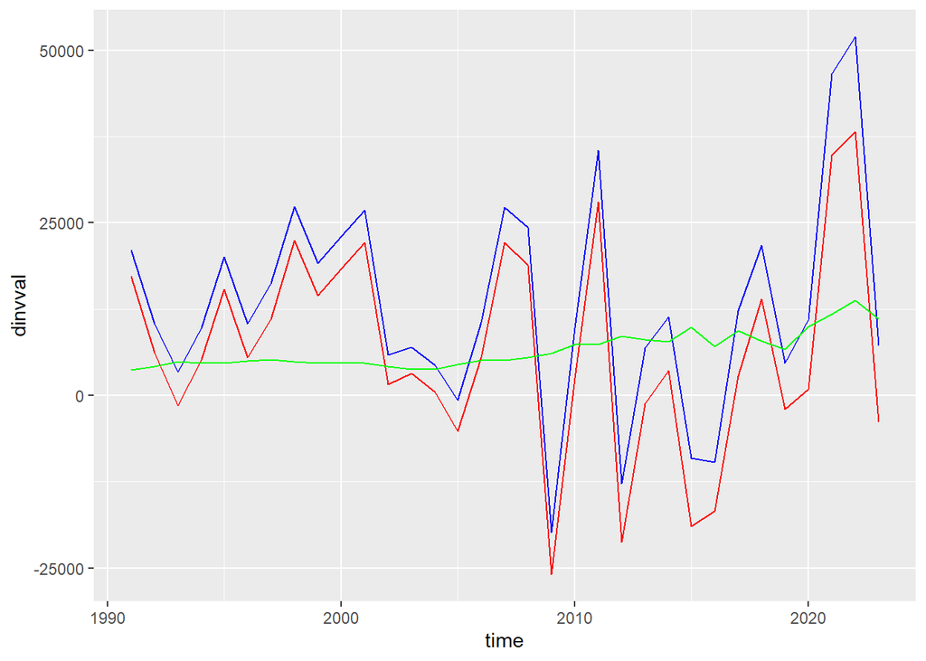

```r
DInvVal <- DInvVal %>%
  mutate(dinvval = dinv + dval)
ggplot(DInvVal) +
  geom_line(aes(x = time, y = dinvval), color = "blue") +
  geom_line(aes(x = time, y = dinv), color = "red") +
  geom_line(aes(x = time, y = dval), color = "green")
```

```r
GDPOutput_model <- model_result$module_collection[[12, "dataset"]][[1]][, c("time", "GDPOutput.level.hat")]
GDPExpenditure_model <- model_result$module_collection[[15, "dataset"]][[1]][, c("time", "GDPExpenditure.level.hat")]
GDP <- full_join(GDPOutput_model, GDPExpenditure_model, by = "time")
View(GDP)
```